# Team 3 R Plots

Vishekha, Vincent, Nishi and Malik

11/12/2019

# **Data Cleaning Documentation**

## Overview

As per our data research questions, we have filtered our dataset from the year 2013 to the year 2017. We could see how the water quality between the two sites changes in these 5 years. We have removed some unnecessary columns and rows to ensure the rationality about the data cleaning. We have combined the day, month, and year column into a single column named Date. We have simplified the column name to make it easier to use. Additionally, we have filled the mean value for temperature in the missing location as the temperature will not vary too much for a given season. In the column ObservationSite, same name has written in different patterns, so we changed it into single pattern (north -> North, west -> West). Also, we have converted all decimal values to 2 decimal points so that it will be easier to read and use the data.

## Issues with the Data Set

Following are the issues that were observed in the data set provided by the stakeholder: * There are three separate columns for a date (Day, Month, Year). * Unnecessary rows and columns are there. * Rows with missing values or no values. * Same name has written in different patterns in the column ObservationSite. * Columns that were supposed to hold numeric values just like other rows in the column but holds value such as NV instead of NULL or be an empty cell. * Number of Decimal places of decimal values is not uniformed along the dataset.

## Instructions

These are the preliminary steps to create MasterWaterQualityEntryAdded.xlsx:  
- Filled in Temperature and Precipitation by using extra spreadsheets from Jesse  
- Calculated the mean for pH, Conductivity, and DissolvedOxygen columns  
- Filled empty cells of pH, Conductivity, and Dissolved columns with the calculated means

# **R plots and R scripts**

## Differences of Turbidity/Conductivity between the North and West sites (using geom point)

```
##
## Call:
## lm(formula = Turbidity ~ Conductivity)
##
## Residuals:
##     Min      1Q  Median      3Q     Max
## -91.730 -19.338  -9.854  16.847  84.467
##
## Coefficients:
##              Estimate Std. Error t value Pr(>|t|)
## (Intercept)  -2.49659    6.36068  -0.393    0.695
## Conductivity  0.07505    0.01157   6.488 6.34e-10 ***
## ---
## Signif. codes:  0 '***' 0.001 '**' 0.01 '*' 0.05 '.' 0.1 ' ' 1
##
## Residual standard error: 28.16 on 206 degrees of freedom.
##   (53 observations deleted due to missingness)
## Multiple R-squared:  0.1697, Adjusted R-squared:  0.1657
## F-statistic:  42.1 on 1 and 206 DF,  p-value: 6.34e-10
```

#### **Plots**

For the two plots below, we are trying to look at the changes in Turbidity/Conductivity between the North and West sites. By using geom point, we can see the changes when the points go up and down. We also faceted the plots based on the years to make sure that we are only comparing the monthly differences of a specific year. Finally, we distinguished the two sites with color.

To interpret these plots, we need to look at the specific month and see if the clusters of points are close to each other which means there is not much of a difference between the two sites. In a perfect world, we expect the cluster of points to lay over each other which means there are no differences. For instance, by looking at September 2015 of the first plot, we can tell that there is a big difference in measurements between the two sites.

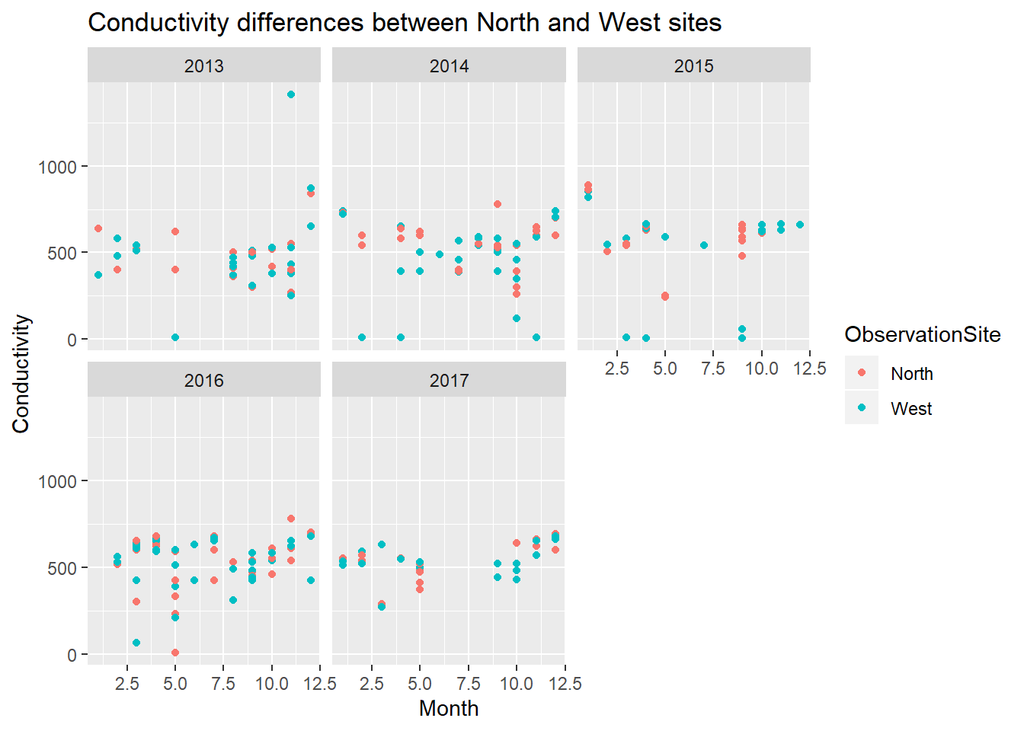

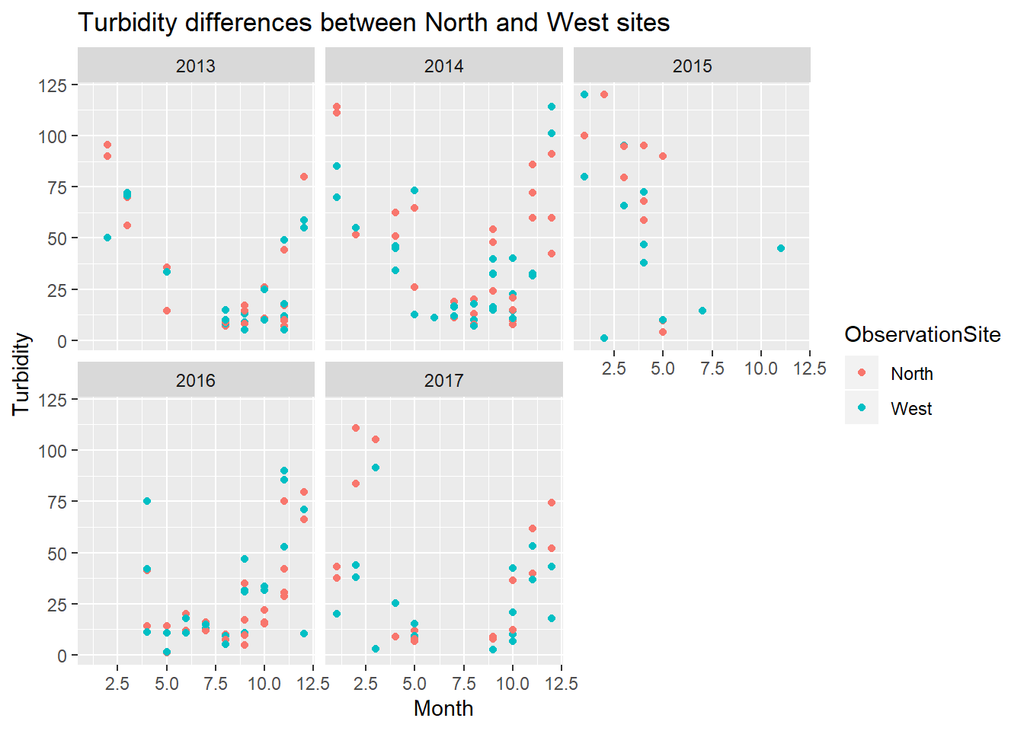